# Visualizations_and_insights

```python
import warnings
warnings.filterwarnings("ignore")
```

```python
import pandas as pd
```

```python
import matplotlib.pyplot as plt
import seaborn as sns
```

```python
cat_data = pd.read_csv('categorical_data.csv')
```

```python
olist = pd.read_csv('OLIST.csv')
```

```python
olist1 = olist.drop( ['product_Computer_Office', 'product_Construction',
       'product_Cosmetics_accessories', 'product_Electronics',
       'product_Furniture', 'product_Health_Medicinies', 'product_Households',
       'product_Sports_Fashion'], axis = 1)
```

```python
olist1['Product'] = cat_data['product']
```

```python
olist1.head()
```

|  | customer_unique_id | price | freight_value | payment_sequential | payment_installments | payment_value | review_score | product_name_lenght | product_description_lenght | product_photos_qty | ... | Delivered_item_in_days | Quickness_in_deliveries_days | Quickness_in_approval_in_days | Quickness_in_loading_in_days | payment_type | Review_Answer_within_days | Delivery_befor_time | Order_frequency | Class | Product |
| --- | --- | --- | --- | --- | --- | --- | --- | --- | --- | --- | --- | --- | --- | --- | --- | --- | --- | --- | --- | --- | --- |
| 0 | 1 | 177.00 | 15.41 | 1.0 | 10.0 | 192.41 | 5 | 57.0 | 2585.0 | 7.0 | ... | 9.0 | 12.000000 | 0.0 | 0.0 | 1 | 2.0 | 3.0 | 1 | 1 | Computer_Office |
| 1 | 2 | 8.88 | 8.29 | 1.0 | 1.0 | 103.02 | 1 | 56.0 | 212.0 | 3.0 | ... | 22.0 | 12.055692 | 3.0 | 20.0 | 1 | 3.0 | 17.0 | 6 | 0 | Computer_Office |
| 2 | 3 | 21.99 | 12.79 | 1.0 | 1.0 | 208.68 | 1 | 60.0 | 662.0 | 1.0 | ... | 6.0 | 12.000000 | 1.0 | 2.0 | 0 | 3.0 | 1.0 | 6 | 0 | Computer_Office |
| 3 | 4 | 199.90 | 27.48 | 1.0 | 1.0 | 454.76 | 5 | 48.0 | 236.0 | 2.0 | ... | 14.0 | 33.000000 | 2.0 | 6.0 | 0 | 0.0 | 6.0 | 2 | 0 | Computer_Office |
| 4 | 5 | 221.99 | 15.64 | 1.0 | 2.0 | 237.63 | 1 | 58.0 | 164.0 | 1.0 | ... | 11.0 | 14.000000 | 0.0 | 4.0 | 1 | 3.0 | 6.0 | 1 | 0 | Computer_Office |

5 rows × 25 columns

# Univariate Analysis

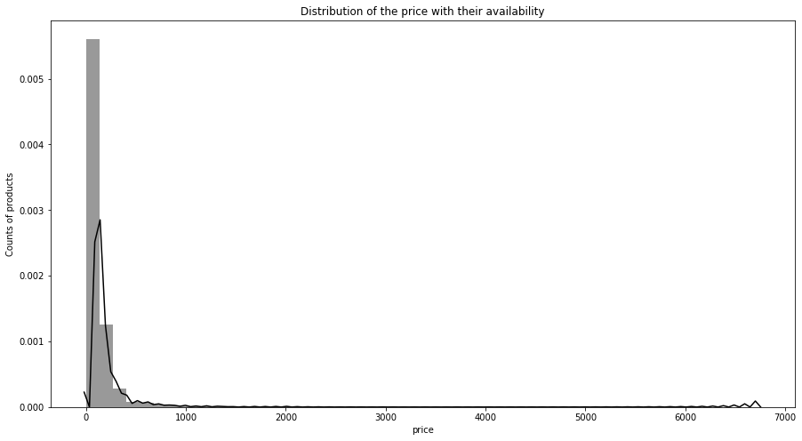

```python
plt.figure(figsize = (15,8))
sns.distplot(olist1.price, color = 'black')
plt.ylabel('Counts of products')
plt.title('Distribution of the price with their availability')
plt.show()
```

We see that, the products of low price are exist in the market in a huge amount, which means peopel are buying these products only. `Let us discuss this further for unique product and its frequency with respect to the customers.`

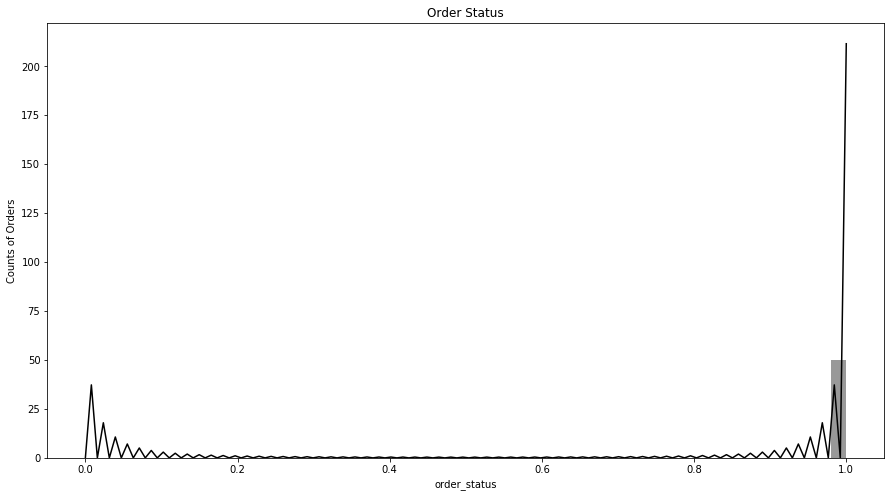

```python
plt.figure(figsize = (15,8))
sns.distplot(olist1.order_status, color = 'black')
plt.ylabel('Counts of Orders')
plt.title('Order Status')
plt.show()
```

From the above plot we can analyse that, there are some orders not delivered, and many orders are delivered. The main thing is to think of non-delivery of the orders. It may be happened becuase of cancellation orders, or the reason of late delivery.

`Let us again see the delivery time status further.`

# Bivariate Analysis

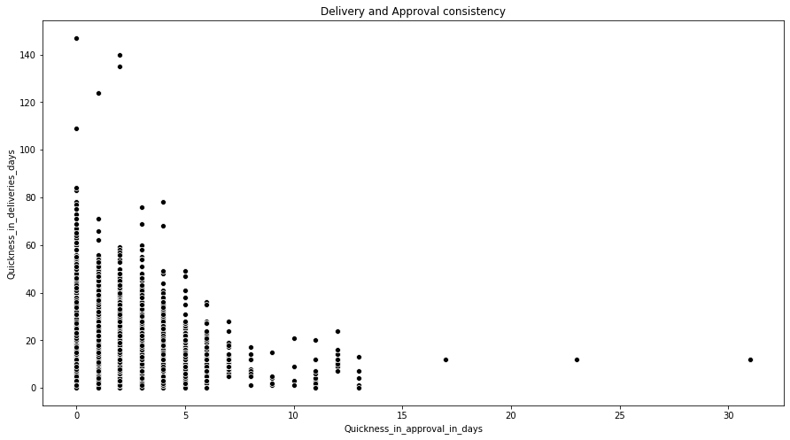

```python
plt.figure(figsize = (15,8))
sns.scatterplot( olist.Quickness_in_approval_in_days, olist.Quickness_in_deliveries_days, color = 'black')
plt.title('Delivery and Approval consistency')
plt.show()
```

- For many orders, we can see that, service approved the order at the same day, but delivery took place after several days.
- We can see there are some orders, which were approaved so late, but delivered so quickly.
- For many orders the order was quite soon approved, but delivery got very much late. ##### This consistency can lead to the loss to the service. The graph should between the range of (0,5) & (0,20). May be this could happened because the longitude and latitude of the area, the order was placed from.

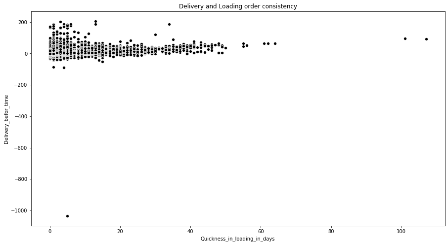

```python
plt.figure(figsize = (15,8))
sns.scatterplot( olist.Quickness_in_loading_in_days, olist.Delivery_befor_time, color = 'black')
plt.title('Delivery and Loading order consistency')
plt.show()
```

Service company should think of it very curiously, this can affect the customer churn.

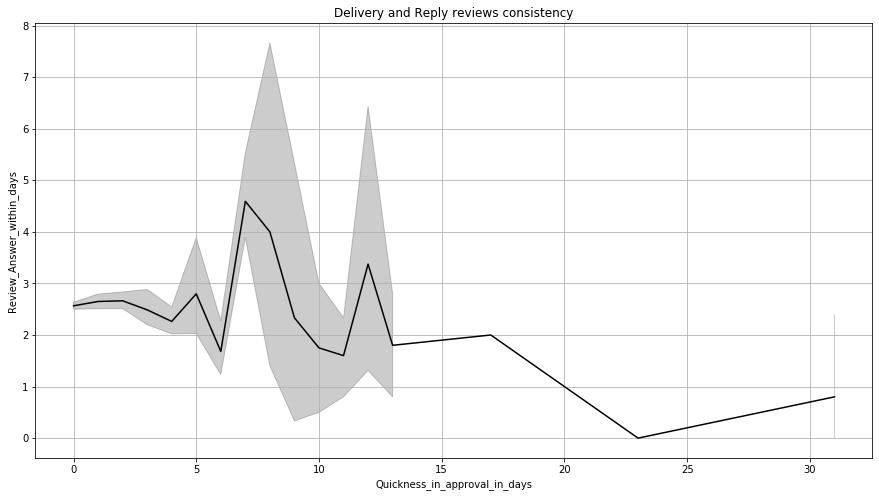

```python
plt.figure(figsize = (15,8))
sns.lineplot( olist.Quickness_in_approval_in_days, olist.Review_Answer_within_days, color = 'black')
plt.title('Delivery and Reply reviews consistency')
plt.grid()
plt.show()
```

- Here we can observe there are huge numbers of datapoints in the range of (0,14) & (0, 7.8).
- The thing we found from the data is, no matter how many days it takes to approve customers' orders, the review is quite late.
- We see that, there are many customers, who got their approval before 15 days, and company answered their review maximum by 8 days, in comparison to the approval time, actually review response is quite faster.

#### What should company do?

Compamy should increase their product availability of each kind of prouct recommended by the customers by their review responses. This issue may be coming because of less availability of products.

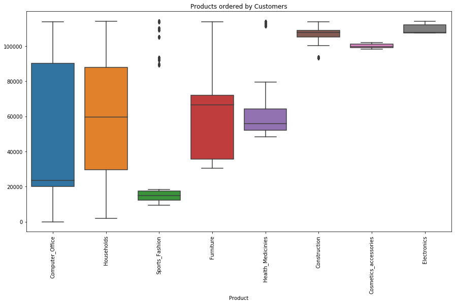

```python
plt.figure(figsize = (15,8))
sns.boxplot(olist1.Product, olist1.index)
plt.title('Products ordered by Customers')
plt.xticks(rotation = 90)
plt.show()
```

- Above plot shows the frequency of the products sold by the service.
- We see that the office atoms and computer stuff are sold very much in this two years. Moreover the households are also having a huge demand in this market.

Let us see the sold atoms distributions:

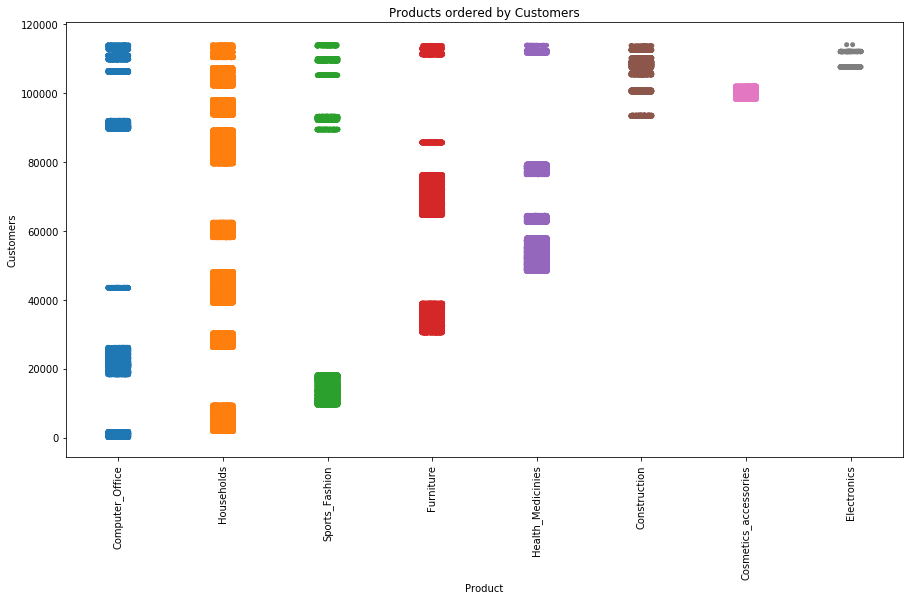

```python
plt.figure(figsize = (15,8))
sns.stripplot(olist1.Product, olist1.index)
plt.ylabel('Customers')
plt.title('Products ordered by Customers')
plt.xticks(rotation = 90)
plt.show()
```

- Like the `boxplot` proved the atoms' consistent selling into the market, but here we see that, consistency of atoms' selling with respect to the customers.
- There are many customers who purchased almost everything from the same service.

  ```
  We can make them a little good offers what they are intrested in purchasing.
  ```

- We can see there are little bit of customers purchased `Electronic` atoms very less, but they bought other atoms from the service.

  ```
  We can even make them an offer for some Electronic and the things the bought very casual.
  ```

- One buisness perspective is, we see that the approach towards the `Electronics` and `Cosmatics and accessories` is quite lower, and remainig all things are in good approach, hence we can solve our above problem by concentrating to the things of good approach.
- This plot again gave a tremendous insight for the data that, `Household` has actually the highest sold by unique customers. #### An approach can be done: Mostly households are bought by the ladies customers, and we see that the frequency of household is quite high. We can make the good offerse to the `Cosmatics and accessories` for the women, so that byhand they will buy some content like `Cosmatics and accessories` with households. We are going to get double benifits from this:
1. Our sale with increase because of good offers, such that women are very curious about shopping.
2. Our `Cosmatics and accessories` has not as good approach as that of other stuffs except from `Electronic`, the sale of same `Cosmatics and accessories` wwill go on peak.

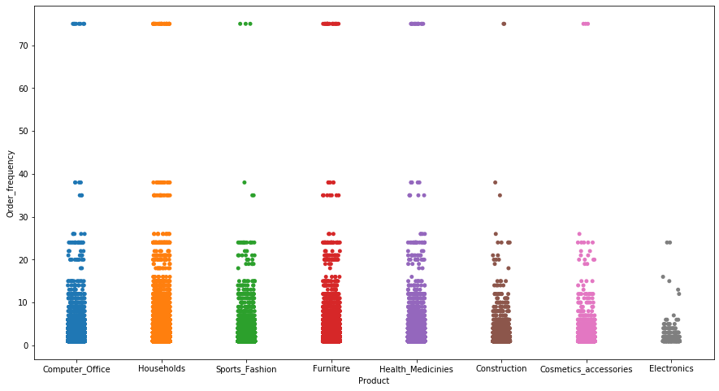

```python
plt.figure(figsize = (15,8))
sns.stripplot(olist1.Product, olist1.Order_frequency)
plt.show()
```

As we have seen from the above plot, the distribution of the Things sold. Here in this plot, again the same summary is visible, since we see that, again `Households` has tremendously high sale ratio than that of other Things.

1. Service should increase the goodness in the product especially households.
2. Service shuould give good offers on households products.
3. Service should think about lady customers and their offers to make them consicutive buyer.

### An Analysis throughout the sale:

- As we have seen that the products of lower price are very much sold, that could be the reason `Cosmatic accessories` are sold lesser, may be the reasom of their expnese.
- Electronic things are expensive but their frequency is lesser, does not make sense the reason of their expens, the reason could be different such that, these are atoms are not bought so casually. In case any `Electronic` thing gets damaged, then only this product is being purchased.

# Multivariate Analysis

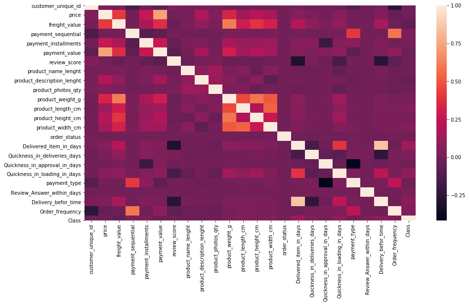

```python
corr = olist1.corr()

plt.figure(figsize = (15,8))
sns.heatmap(corr)
plt.show()
```

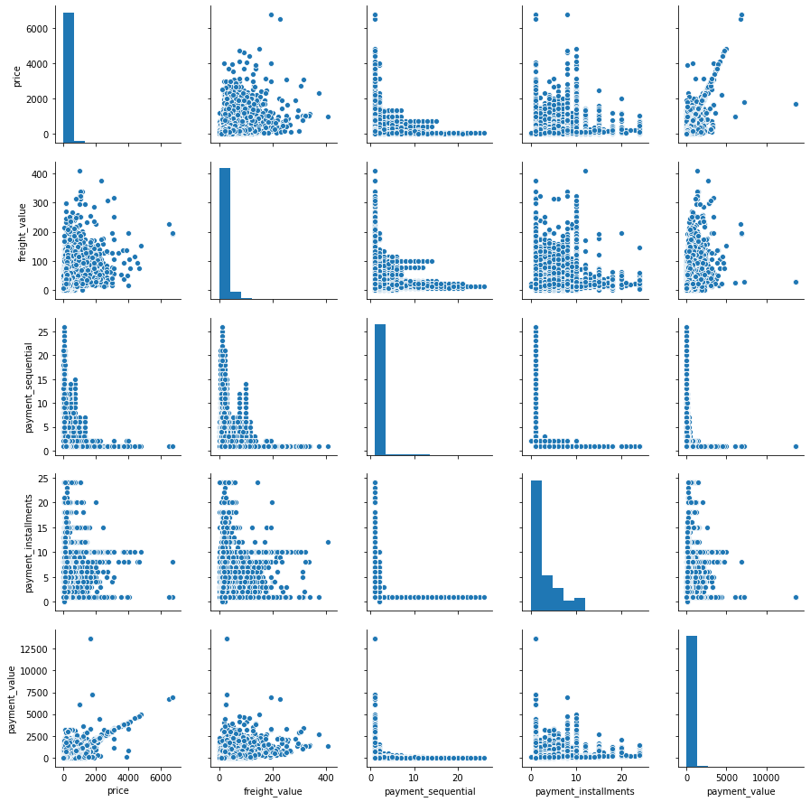

```python
sns.pairplot(olist1.iloc[:, 1:6])
plt.show()
```

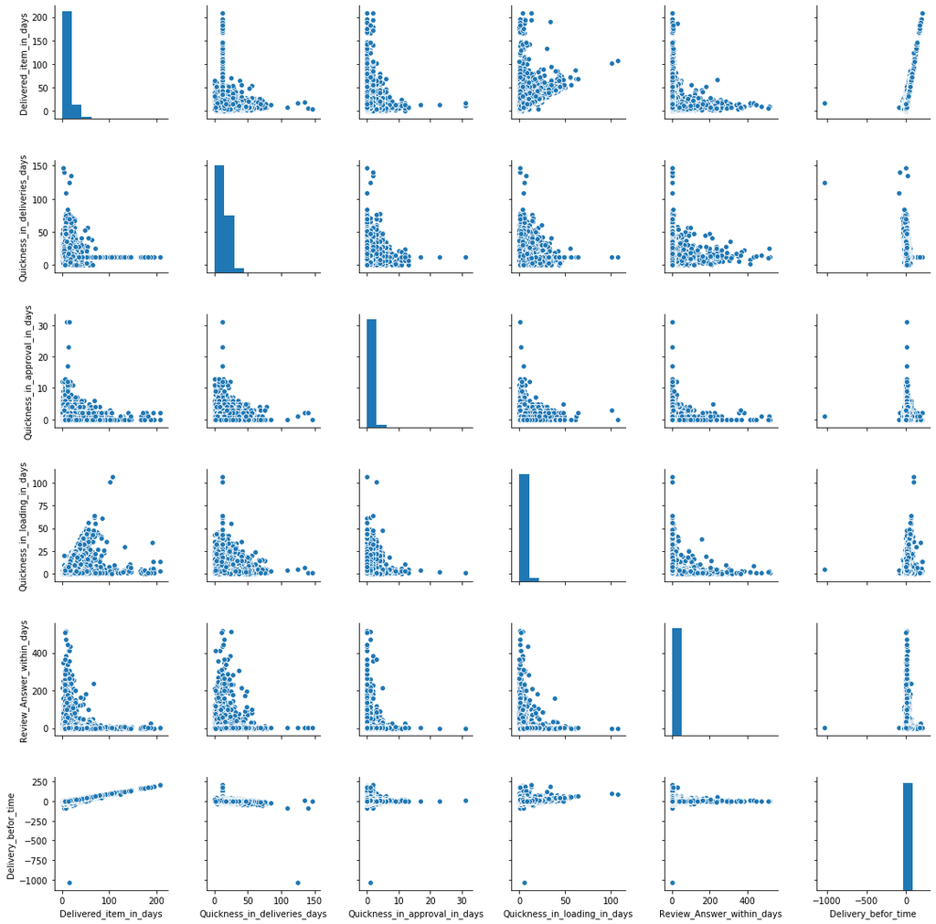

```python
sns.pairplot(olist1.loc[:, ['Delivered_item_in_days', 'Quickness_in_deliveries_days',
       'Quickness_in_approval_in_days', 'Quickness_in_loading_in_days',
        'Review_Answer_within_days', 'Delivery_befor_time',]])
plt.show()
```

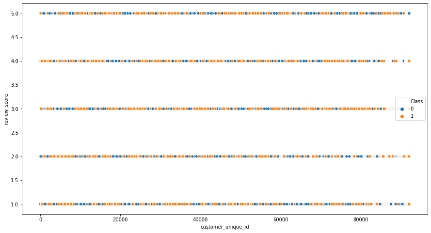

```python
plt.figure(figsize = (15,8))
sns.scatterplot(olist1.customer_unique_id, olist1.review_score, hue = olist1.Class)
plt.show()
```

Company needs to find out the reason of churning those many satisfied customers, and focus on them.

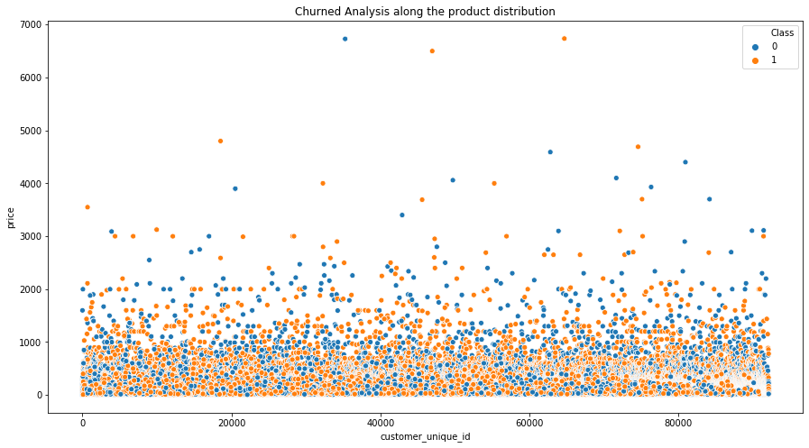

```python
plt.figure(figsize = (15,8))
sns.scatterplot(olist1.customer_unique_id, olist1.price, hue = olist1.Class)
plt.title('Churned Analysis along the product distribution')
plt.show()
```

We see here that, most of the churned and non-churned customers are exist in the very low price range, Let us have a look on those customers who puurchase the orders in expensive range.

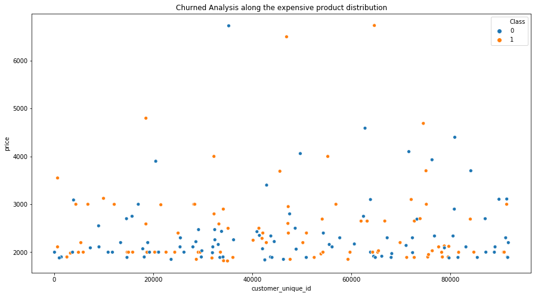

```python
plt.figure(figsize = (15,8))
sns.scatterplot(olist1[olist1.price>1800].customer_unique_id, olist1[olist1.price>1800].price,
                hue = olist1[olist1.price>1800].Class)
plt.title('Churned Analysis along the expensive product distribution')
plt.show()
```

```python
olist1[olist1.price>1800].Class.value_counts(normalize = True)
```

```
0    0.527919
1    0.472081
Name: Class, dtype: float64
```

It is an awesome analysis we had, the churned are lesser than that of non-churned in expensive seller range, which means the customers have ability of purchasing the expensive stuffs are stayed with service.

#### What should company do for such customers?

Comapamny should either bestow them a good discount or some good offers with the expensive products along cheap things. This could again improve the percent of non-churned customers.

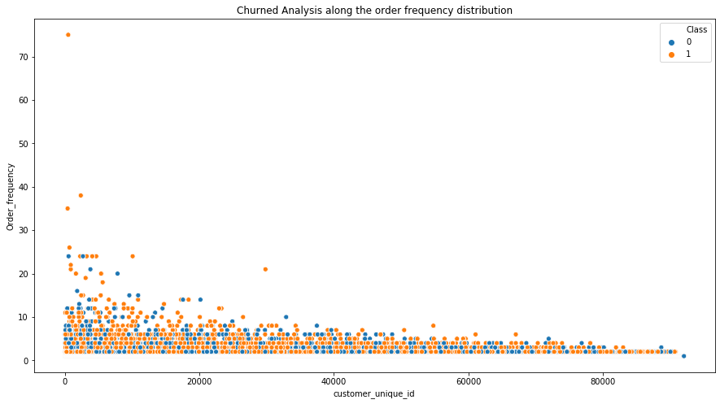

```python
plt.figure(figsize = (15,8))
sns.scatterplot(olist1.customer_unique_id, olist1.Order_frequency, hue = olist1.Class)
plt.title('Churned Analysis along the order frequency distribution')
plt.show()
```

Here we got a disgusting analysis. We see that, the customers ordered in higher frequency they are churning the service. May be they could be doing cheap orders consecutively. But company needs to be thinking about those customers, that `what happened to them that they are not anymore intersted in the service despite of so much shopping?`

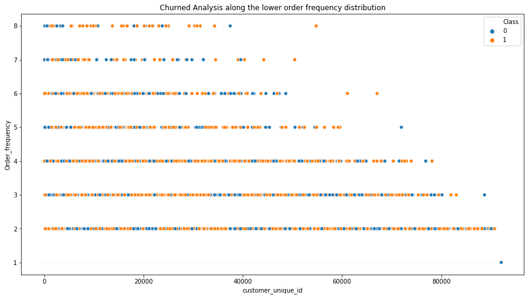

```python
plt.figure(figsize = (15,8))
sns.scatterplot(olist1[olist1.Order_frequency<9].customer_unique_id, olist1[olist1.Order_frequency<9].Order_frequency,
                hue = olist1[olist1.Order_frequency<9].Class)
plt.title('Churned Analysis along the lower order frequency distribution')
plt.show()
```

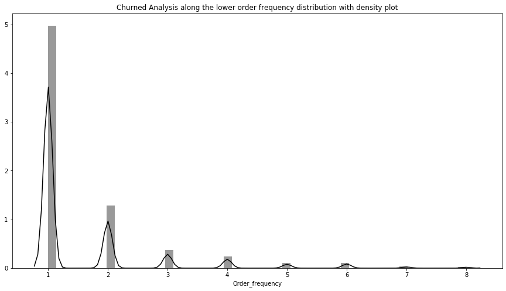

```python
plt.figure(figsize = (15,8))
sns.distplot(olist1[olist1.Order_frequency<9].Order_frequency, color = 'black')
plt.title('Churned Analysis along the lower order frequency distribution with density plot')
plt.show()
```

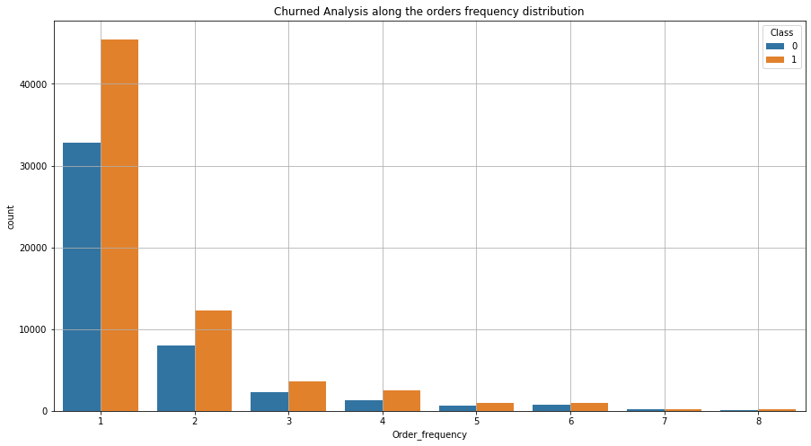

```python
plt.figure(figsize = (15,8))
sns.countplot(data=olist1[olist1.Order_frequency<9], x='Order_frequency', hue='Class')
plt.title('Churned Analysis along the orders frequency distribution')
plt.grid()
plt.show()
```

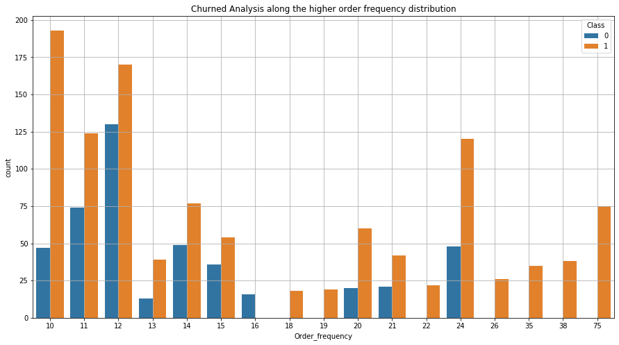

```python
plt.figure(figsize = (15,8))
sns.countplot(data=olist1[olist1.Order_frequency>9], x='Order_frequency', hue='Class')
plt.title('Churned Analysis along the higher order frequency distribution')
plt.grid()
plt.show()
```

`Stack-bar analysis`

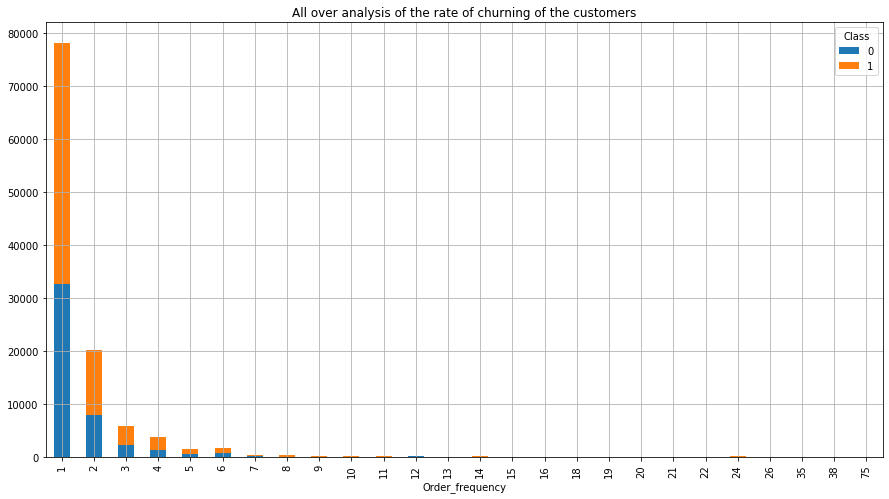

```python
plt.rcParams['figure.figsize'] = [15,8]
pd.crosstab(olist1.Order_frequency, olist1.Class).plot(kind='bar', stacked=True)
plt.title('All over analysis of the rate of churning of the customers')
plt.grid()
plt.show()
```

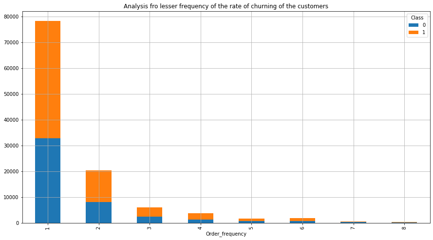

```python
plt.rcParams['figure.figsize'] = [15,8]
pd.crosstab(olist1[olist1.Order_frequency<9].Order_frequency,
            olist1[olist1.Order_frequency<9].Class).plot(kind='bar', stacked=True)
plt.title('Analysis fro lesser frequency of the rate of churning of the customers')
plt.grid()
plt.show()
```

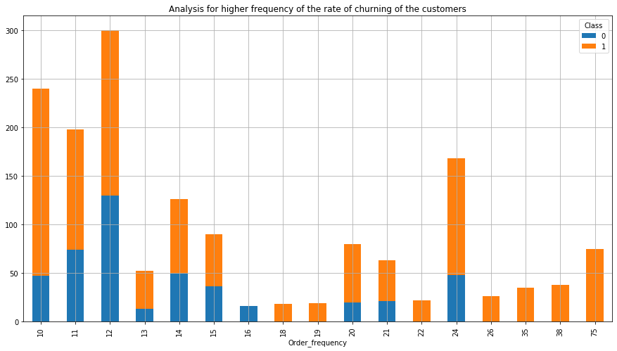

```python
plt.rcParams['figure.figsize'] = [15,8]
pd.crosstab(olist1[olist1.Order_frequency>9].Order_frequency,
            olist1[olist1.Order_frequency>9].Class).plot(kind='bar', stacked=True)
plt.title('Analysis for higher frequency of the rate of churning of the customers')
plt.grid()
plt.show()
```

### Insights from above `Frequency` vs `Class` plots:

  ```
    Occasionally
    Any electronic product which is casually ordered by its long damage only.
  ```

#### How should company manage this order frequency scenario?

- Company should offer them a good offer so that, they could purchase more than one product at a time, by which the order frequency will increase.
- The customers buying occasionally with low frequency, company should offer them some household products with reasonable price, if their count doesn't improve, then no benifit to entertain them. If they leave company does not suffer any huge difference.
- By messaging or call, attract those customers who are regular in ordering, get the knowledge of their leaving of the service. And `increase the staff` to place the order on the time. This could definitely remain them connecetd.
- Company should think of the reason of such scenario of high rate churn all along the buisness.

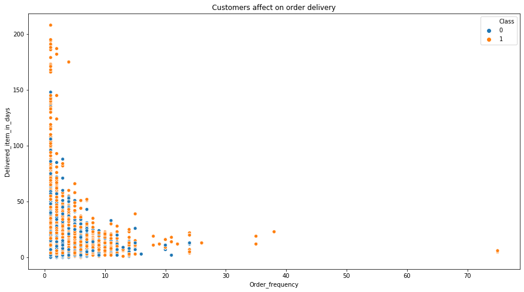

```python
plt.figure(figsize = (15,8))
sns.scatterplot(olist1.Order_frequency, olist1.Delivered_item_in_days, hue = olist.Class )
plt.title('Customers affect on order delivery')
plt.show()
```

```python
olist1[olist.Delivered_item_in_days>50]['Class'].value_counts(normalize = True)
```

```
1    0.719718
0    0.280282
Name: Class, dtype: float64
```

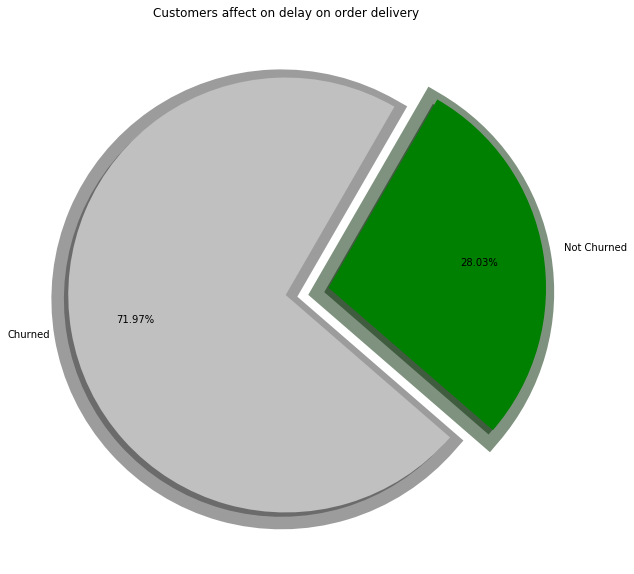

```python
plt.figure(figsize = (10,10))
plt.pie(olist1[olist.Delivered_item_in_days>50]['Class'].value_counts(), autopct = '%1.2f%%',
        explode = [0.0,0.2],
        colors = ['silver', 'green'],
        labels = ['Churned', 'Not Churned'],
       shadow = True, wedgeprops = {'linewidth': 25}  , pctdistance= 0.7, startangle = 60)
plt.title('Customers affect on delay on order delivery')
plt.show()
```

- As we have mentioned the cause of churning above, we see here the similar output from our analysis.
- Most of customers became churned because of the delay in the delivery. As we can see the higher delay caused `72%` churning in the customers.
- One more irrelavent fact to analysed that, the customers left the survice was not the cause of delay in oredr what we have mentioned in above analysis content. Then there could be two reasons they left the service:

  ```
    May be they are no more exist (Embarrassed to say)
    OR they may be having another service which is offering more services to the customers.
  ```

#### Company should think of this frequency. A call again can get them back with some good offers.